# FPCC2 - Lab01 - Checkpoint 02

Anderson Gustafson

## Dados

Os dados que são a base da análise descrevem os gastos realizados pelos deputados brasileiros no ano de 2016. Estes dados são abertos e disponibilizados pela própria câmara legislativa e podem ser encontrados neste link: [Site da câmara](http://www2.camara.leg.br/transparencia/cota-para-exercicio-da-atividade-parlamentar/dados-abertos-cota-parlamentar)

```r
gastos_gerais = read_csv(file = "../data/gastos-cota_atividade_parlamentar.csv")
```

Além disso, iremos focar os estudos nos gastos realizados unicamente pelos parlamentares da Paraíba.

```r
gastos_pb = gastos_gerais %>%
  select(sgPartido, numAno, numMes, vlrGlosa, txNomeParlamentar, vlrDocumento, txtDescricao, txtFornecedor, vlrLiquido, txtPassageiro, txtTrecho, sgUF, nuDeputadoId, numSubCota) %>%
  filter(sgUF == "PB")
```

Antes de tudo vamos dar uma olhada em quem são e quantos deputados temos no estado e quais as categorias de gastos declaradas.

```r
parlamentares_pb = gastos_pb %>%
  select(txNomeParlamentar, sgPartido, nuDeputadoId) %>%
  distinct(txNomeParlamentar, sgPartido, nuDeputadoId)
  colnames(parlamentares_pb) = c("Nome_do_Parlamentar", "Partido", "Id")
  print(parlamentares_pb %>% select(Nome_do_Parlamentar, Partido ))
```

```
## # A tibble: 17 x 2
##        Nome_do_Parlamentar Partido
##                      <chr>   <chr>
## 1        AGUINALDO RIBEIRO      PP
## 2        BENJAMIN MARANHÃO      SD
## 3         DAMIÃO FELICIANO     PDT
## 4             EFRAIM FILHO     DEM
## 5               HUGO MOTTA    PMDB
## 6               LUIZ COUTO      PT
## 7            MANOEL JUNIOR    PMDB
## 8        MARCONDES GADELHA     PSC
## 9         PEDRO CUNHA LIMA    PSDB
## 10          RÔMULO GOUVEIA     PSD
## 11 VENEZIANO VITAL DO RÊGO    PMDB
## 12      WELLINGTON ROBERTO      PR
## 13            WILSON FILHO     PTB
## 14             MAJOR FÁBIO    PROS
## 15            NILDA GONDIM    PMDB
## 16            RUY CARNEIRO    PSDB
## 17            ANDRÉ AMARAL    PMDB
```

```r
tipoDeGastos = gastos_pb%>%
  select(txtDescricao, numSubCota)%>%
  unique()
  colnames(tipoDeGastos) = c("Despesa", "ID")
  print(tipoDeGastos %>% select(ID, Despesa))
```

```
## # A tibble: 15 x 2
##       ID                                                   Despesa
##    <int>                                                     <chr>
## 1      1 MANUTENÇÃO DE ESCRITÓRIO DE APOIO À ATIVIDADE PARLAMENTAR
## 2      3                             COMBUSTÍVEIS E LUBRIFICANTES.
## 3      5                      DIVULGAÇÃO DA ATIVIDADE PARLAMENTAR.
## 4      9                                          PASSAGENS AÉREAS
## 5     10                                                 TELEFONIA
## 6     11                                          SERVIÇOS POSTAIS
## 7     12                                 ASSINATURA DE PUBLICAÇÕES
## 8    120             LOCAÇÃO OU FRETAMENTO DE VEÍCULOS AUTOMOTORES
## 9    999                                     Emissão Bilhete Aéreo
## 10     4             CONSULTORIAS, PESQUISAS E TRABALHOS TÉCNICOS.
## 11    13                FORNECIMENTO DE ALIMENTAÇÃO DO PARLAMENTAR
## 12    14    HOSPEDAGEM ,EXCETO DO PARLAMENTAR NO DISTRITO FEDERAL.
## 13   122                 SERVIÇO DE TÁXI, PEDÁGIO E ESTACIONAMENTO
## 14     8  SERVIÇO DE SEGURANÇA PRESTADO POR EMPRESA ESPECIALIZADA.
## 15   119                        LOCAÇÃO OU FRETAMENTO DE AERONAVES
```

Como visto na tabela acima, existe uma categoria denomidada **Emissão Bilhete Aéreo** e outra denominada **PASSAGENS AÉREAS** o que provavelmente indica ser uma só categoria que foi dividida em duas por alguma razão. Para facilitar o entendimento e análise vamos juntar essas duas categorias e tratá-las como **PASSAGENS AÉREAS**.

```r
gastos_pb$txtDescricao[gastos_pb$txtDescricao == "Emissão Bilhete Aéreo"] <- "PASSAGENS AÉREAS"
gastos_pb$numSubCota[gastos_pb$numSubCota == 9] <- 999
```

```r
pb_2016 = gastos_pb %>%
  filter(numAno == 2016)

pb_2016_agrupado =  pb_2016%>%
  group_by(numMes, txtDescricao) %>%
  summarise(total_gasto = sum(vlrLiquido))
```

Passeando pelos dados foi possível observar que existem valores negativos como **Valor Líquido** da despesa. Investigando um pouco mais ficou claro que esses valores são estornos de companhias aéreas. Portanto, os valores negativos se anulam com valores positivos, representando, respectivamente, estornos de pagamentos feitos anteriormente. Podemos observar esses valores *estranhos* no sumário indicado abaixo.

```r
summary(pb_2016$vlrLiquido)
```

```
##    Min. 1st Qu.  Median    Mean 3rd Qu.    Max.
## -2820.0    73.2   200.0   844.4   680.5 73420.0
```

O gráfico abaixo identifica quais categorias concentram os maiores gastos dos nossos *amigos parlamentares*.

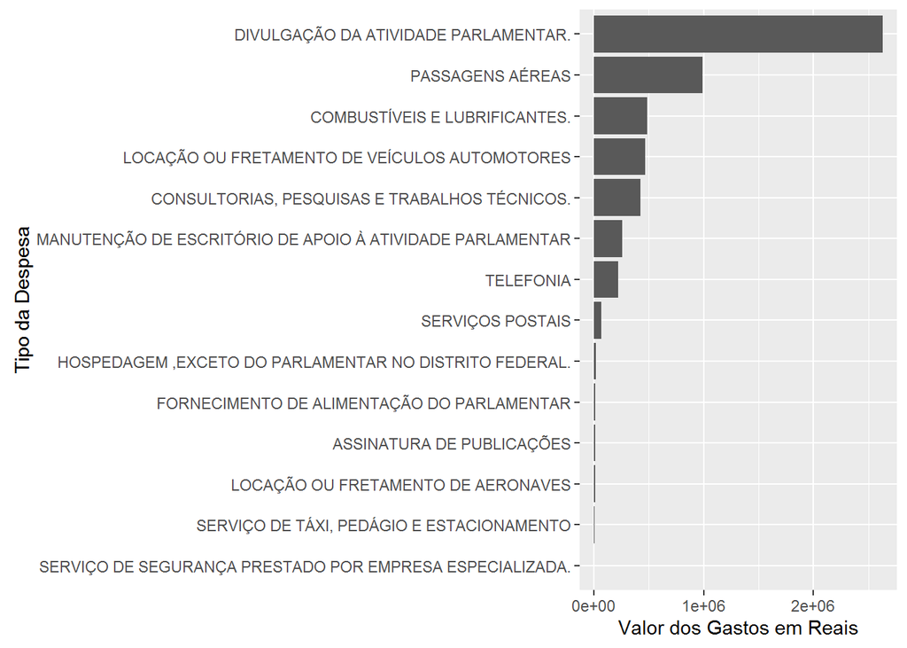

```r
pb_por_tipo = pb_2016 %>%
  select(txtDescricao, vlrLiquido) %>%
  group_by(txtDescricao)%>%
  summarise(total_gasto = sum(vlrLiquido))

ggplot(pb_por_tipo, aes(x=reorder(txtDescricao, total_gasto), y=total_gasto)) +
  geom_bar(stat = "identity") +
  coord_flip() +
  labs(x='Tipo da Despesa', y='Valor dos Gastos em Reais')
```

Já o próximo gráfico nos indica quais categorias de gastos que apresentam maior variação de valores

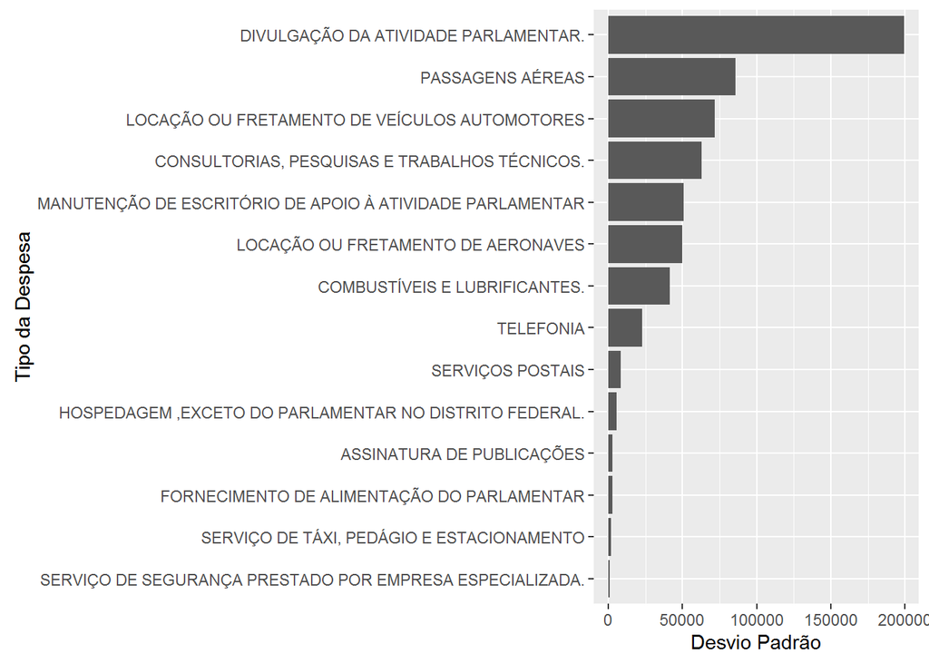

```r
pb_agrupado_parl_tipo = gastos_pb %>%
  select(txNomeParlamentar, txtDescricao, vlrLiquido) %>%
  group_by(txNomeParlamentar, txtDescricao) %>%
  summarise(total_gasto = sum(vlrLiquido))

pb_dp = pb_agrupado_parl_tipo %>%
  group_by(txtDescricao) %>%
  summarise(desvio_padrao = sd(total_gasto))

ggplot(pb_dp, aes(x=reorder(txtDescricao, desvio_padrao), y=desvio_padrao)) +
  geom_bar(stat = "identity") +
  labs(x='Tipo da Despesa', y='Desvio Padrão')+
  coord_flip()
```

Percebemos que **Divulgação da Atividade Parlamentar** está no topo dos dois gráficos, sendo onde mais se gasta dinheiro e também onde existe a maior variação dos valores gastos.

Tentando ver a distribuiçao de outra forma, é possível dizer que 75% dos gastos em **Divulgação da Atividade Parlamentar** não variam tanto, mas os outros 25% *que mais gastam* possui valores bem diferentes dos demais.

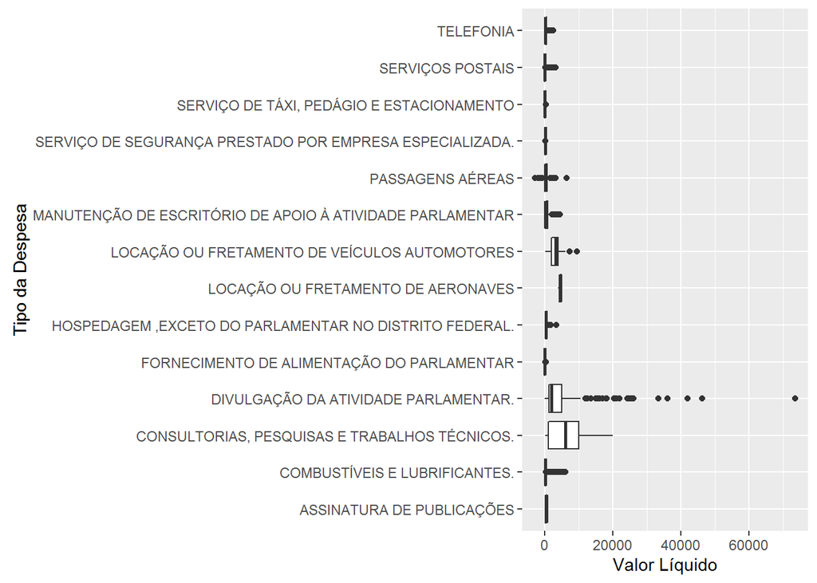

```r
ggplot(data = pb_2016, aes(x= txtDescricao, y=vlrLiquido)) +
  geom_boxplot() +
  labs(x='Tipo da Despesa', y='Valor Líquido') +
  coord_flip()
```

Expandindo a categoria **Divulgação da Atividade Parlamentar** vemos que *Manoel Júnior* foi quem mais gastou (R$ 73420,00 em 11/2016) seguido por *Benjamin Maranhão* com um gasto de R$ 46150,00 em 12/2016.

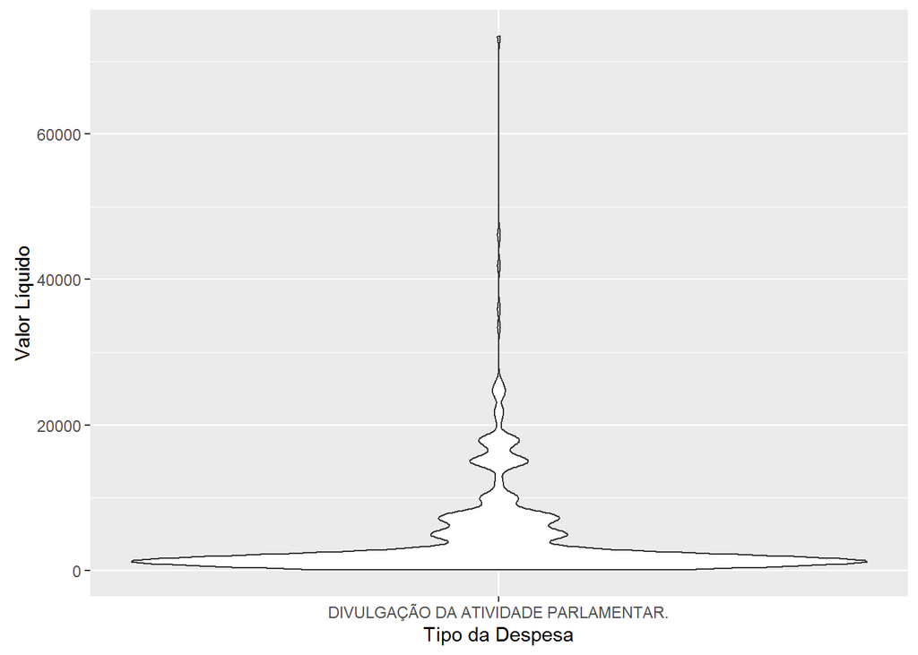

```r
divulgacao_2016 = pb_2016 %>%
  filter(txtDescricao == "DIVULGAÇÃO DA ATIVIDADE PARLAMENTAR.")

ggplot(divulgacao_2016, aes(x= txtDescricao, y=vlrLiquido)) +
  geom_violin() +
  labs(x='Tipo da Despesa', y='Valor Líquido')
```

```r
divulgacao_ordenada = divulgacao_2016[order(-divulgacao_2016$vlrLiquido), ]

head(divulgacao_ordenada)
```

```
## # A tibble: 6 x 14
##   sgPartido numAno numMes vlrGlosa  txNomeParlamentar vlrDocumento
##       <chr>  <int>  <int>    <dbl>              <chr>        <dbl>
## 1      PMDB   2016     11        0      MANOEL JUNIOR        73420
## 2        SD   2016     12        0  BENJAMIN MARANHÃO        46150
## 3        SD   2016      5        0  BENJAMIN MARANHÃO        41890
## 4        PR   2016     12        0 WELLINGTON ROBERTO        36000
## 5       DEM   2016      8        0       EFRAIM FILHO        33450
## 6       PTB   2016     12        0       WILSON FILHO        26092
## # ... with 8 more variables: txtDescricao <chr>, txtFornecedor <chr>,
## #   vlrLiquido <dbl>, txtPassageiro <chr>, txtTrecho <chr>, sgUF <chr>,
## #   nuDeputadoId <int>, numSubCota <dbl>
```